# funModeling quick-start

Almost no explanations here, just go to the point: problem + code + solutions.

Most of the `funModeling` functions are intendeed to work with one or many variables at once.

## Dataset health

#### `df_status`

Use case: analyze the zeros, missing values (`NA`), infinity, data type and number of unique values for a given dataset.

```r
library(funModeling)

df_status(heart_disease)
```

```
##                  variable q_zeros p_zeros q_na p_na q_inf p_inf    type
## 1                     age       0    0.00    0 0.00     0     0 integer
## 2                  gender       0    0.00    0 0.00     0     0  factor
## 3              chest_pain       0    0.00    0 0.00     0     0  factor
## 4  resting_blood_pressure       0    0.00    0 0.00     0     0 integer
## 5       serum_cholestoral       0    0.00    0 0.00     0     0 integer
## 6     fasting_blood_sugar     258   85.15    0 0.00     0     0  factor
## 7         resting_electro     151   49.83    0 0.00     0     0  factor
## 8          max_heart_rate       0    0.00    0 0.00     0     0 integer
## 9             exer_angina     204   67.33    0 0.00     0     0 integer
## 10                oldpeak      99   32.67    0 0.00     0     0 numeric
## 11                  slope       0    0.00    0 0.00     0     0 integer
## 12      num_vessels_flour     176   58.09    4 1.32     0     0 integer
## 13                   thal       0    0.00    2 0.66     0     0  factor
## 14 heart_disease_severity     164   54.13    0 0.00     0     0 integer
```

[output cut: 19 more lines]

Questions:

- Does every variable has the correct data type? if not, how to transform them according to project needs?
- Is it ok that certain variable has several NAs, zeros and/or infinite values?
- What are the high cardinality variables (`unique > 30`)? What to do with them?

🔎 [Read more here.](https://livebook.datascienceheroes.com/exploratory-data-analysis.html#dataset-health-status)

## Exploratory data analysis

#### `plot_num`: Plotting distributions for numerical variables.

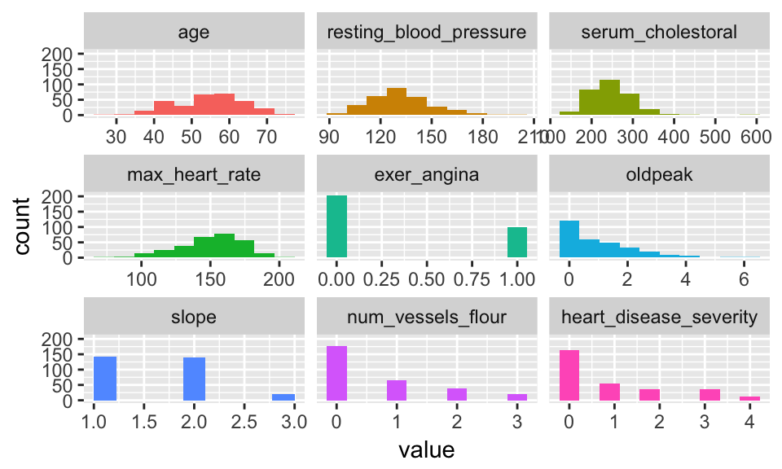

```r
plot_num(heart_disease)
```

🔎 [Read more here.](https://livebook.datascienceheroes.com/exploratory-data-analysis.html#plotting-numerical-variable)

#### `profiling_num`: Calculating several statistics for numeric variables.

```r
profiling_num(heart_disease)
```

```
##                 variable   mean std_dev variation_coef p_01 p_05 p_25
## 1                    age  54.44    9.04           0.17   35   40   48
## 2 resting_blood_pressure 131.69   17.60           0.13  100  108  120
## 3      serum_cholestoral 246.69   51.78           0.21  149  175  211
## 4         max_heart_rate 149.61   22.88           0.15   95  108  134
## 5            exer_angina   0.33    0.47           1.44    0    0    0
## 6                oldpeak   1.04    1.16           1.12    0    0    0
## 7                  slope   1.60    0.62           0.38    1    1    1
## 8      num_vessels_flour   0.67    0.94           1.39    0    0    0
## 9 heart_disease_severity   0.94    1.23           1.31    0    0    0
##    p_50  p_75  p_95  p_99 skewness kurtosis  iqr        range_98
## 1  56.0  61.0  68.0  71.0    -0.21      2.5 13.0        [35, 71]
## 2 130.0 140.0 160.0 180.0     0.70      3.8 20.0      [100, 180]
## 3 241.0 275.0 326.9 406.7     1.13      7.4 64.0   [149, 406.74]
## 4 153.0 166.0 181.9 192.0    -0.53      2.9 32.5 [95.02, 191.96]
## 5   0.0   1.0   1.0   1.0     0.74      1.5  1.0          [0, 1]
## 6   0.8   1.6   3.4   4.2     1.26      4.5  1.6        [0, 4.2]
## 7   2.0   2.0   3.0   3.0     0.51      2.4  1.0          [1, 3]
## 8   0.0   1.0   3.0   3.0     1.18      3.2  1.0          [0, 3]
## 9   0.0   2.0   3.0   4.0     1.05      2.8  2.0          [0, 4]
##         range_80
## 1       [42, 66]
## 2     [110, 152]
## 3 [188.8, 308.8]
## 4   [116, 176.6]
## 5         [0, 1]
## 6       [0, 2.8]
## 7         [1, 2]
## 8         [0, 2]
## 9         [0, 3]
```

Note: `plot_num` and `profiling_num` automatically exclude non-numeric variables

🔎 [Read more here.](https://livebook.datascienceheroes.com/exploratory-data-analysis.html#numerical-profiling-in-r)

#### `freq`: Getting frequency distribution for categoric variable

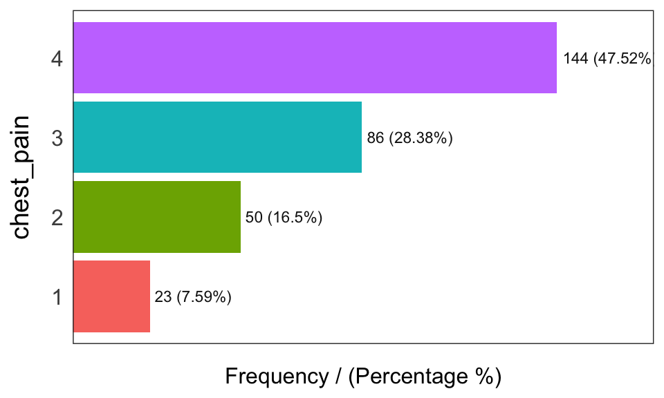

```
##   chest_pain frequency percentage cumulative_perc
## 1          4       144       47.5              48
## 2          3        86       28.4              76
## 3          2        50       16.5              92
## 4          1        23        7.6             100
```

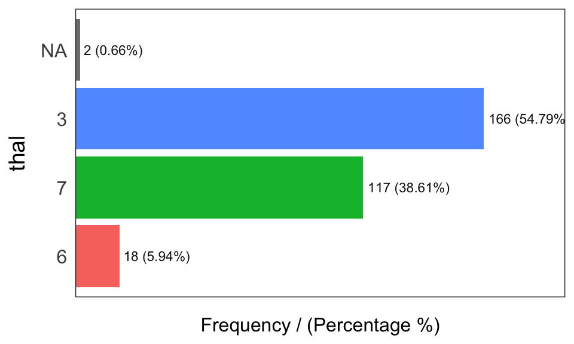

```
##   thal frequency percentage cumulative_perc
## 1    3       166      54.79              55
## 2    7       117      38.61              93
## 3    6        18       5.94              99
## 4 <NA>         2       0.66             100
```

```
## [1] "Variables processed: chest_pain, thal"
```

```r
library(dplyr)

# select only two variables for this example
heart_disease_2=heart_disease %>% select(chest_pain, thal)

# frequency distribution
freq(heart_disease_2)
```

Note:

- `freq` only processes `factor` and `character`, excluding non-categorical variables.
- It returns a distribution table.

🔎 [Read more here.](https://livebook.datascienceheroes.com/exploratory-data-analysis.html#profiling-categorical-variables)

## Correlation

Use case: get correlation between input and target variable

#### `correlation_table`: Calculates R statistic

It retrieves R metric (or Pearson coefficient) for all numeric variables skipping the categorical ones.

```r
correlation_table(heart_disease, "has_heart_disease")
```

```
##                 Variable has_heart_disease
## 1      has_heart_disease              1.00
## 2 heart_disease_severity              0.83
## 3      num_vessels_flour              0.46
## 4                oldpeak              0.42
## 5                  slope              0.34
## 6                    age              0.23
## 7 resting_blood_pressure              0.15
## 8      serum_cholestoral              0.08
## 9         max_heart_rate             -0.42
```

Note: Only numeric variables are analyzed. Target variable must be numeric.

🔎 [Read more here.](https://livebook.datascienceheroes.com/exploratory-data-analysis.html#linear-correlation)

#### `var_rank_info`: Correlation based on information theory

Calculates correlation based on several information theory metrics between all variables in a data frame and a target variable.

```r
var_rank_info(heart_disease, "has_heart_disease")
```

```
##                       var  en    mi      ig      gr
## 1  heart_disease_severity 1.8 0.995 0.99508 0.53907
## 2                    thal 2.0 0.209 0.20946 0.16805
## 3             exer_angina 1.8 0.139 0.13914 0.15264
## 4            exter_angina 1.8 0.139 0.13914 0.15264
## 5              chest_pain 2.5 0.205 0.20502 0.11803
## 6       num_vessels_flour 2.4 0.182 0.18152 0.11577
## 7                   slope 2.2 0.112 0.11242 0.08688
## 8       serum_cholestoral 7.5 0.561 0.56056 0.07956
## 9                  gender 1.8 0.057 0.05725 0.06330
## 10                oldpeak 4.9 0.249 0.24917 0.06036
## 11         max_heart_rate 6.8 0.334 0.33362 0.05407
## 12 resting_blood_pressure 5.6 0.143 0.14255 0.03024
## 13                    age 5.9 0.137 0.13718 0.02705
## 14        resting_electro 2.1 0.024 0.02415 0.02219
## 15    fasting_blood_sugar 1.6 0.000 0.00046 0.00076
```

Note: It analyzes numerical and categorical variables. Also used with a numerical discretization method before, just as `discretize_df`.

Questions:

- What is the rank of most important variables given? Metrics: Pearson, mutual information, gain ratio, etc.

🔎 [Read more here.](https://livebook.datascienceheroes.com/selecting-best-variables.html#select_features_var_rank_info)

#### `cross_plot`: Distribution plot between input and target variable

Retrieves the relative and absolute distribution between an input and target variable.

```
## [1] "Plotting transformed variable 'age' with 'equal_freq', (too many values). Disable with 'auto_binning=FALSE'"
```

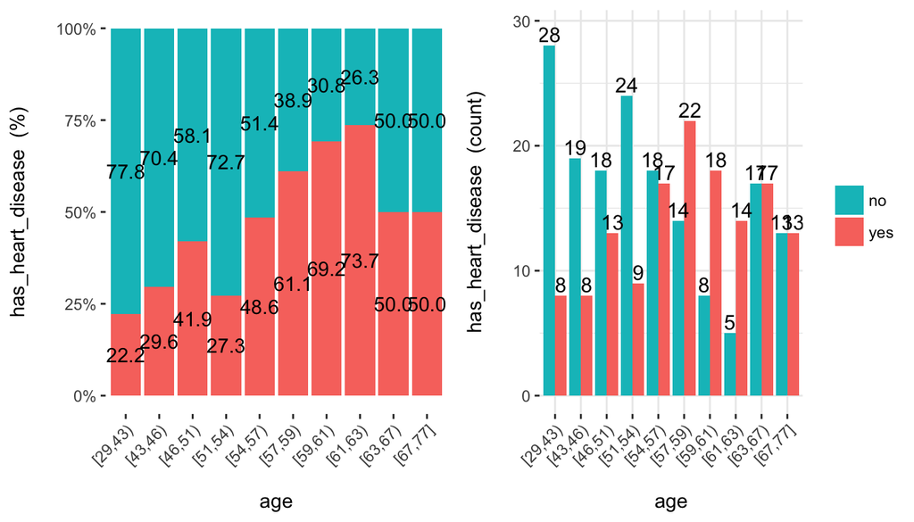

```
## [1] "Plotting transformed variable 'oldpeak' with 'equal_freq', (too many values). Disable with 'auto_binning=FALSE'"
```

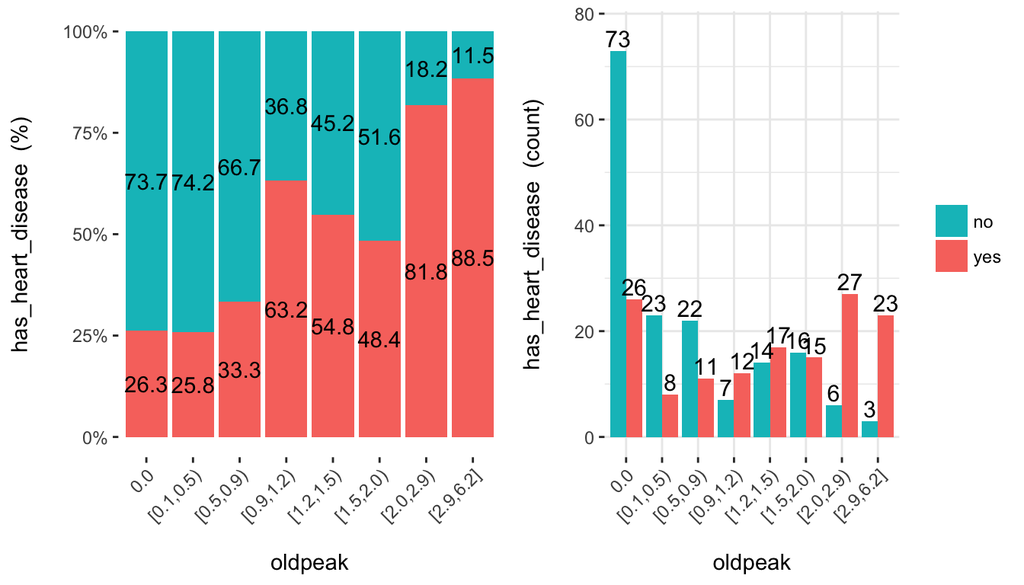

```r
cross_plot(data=heart_disease, str_input=c("age", "oldpeak"), str_target="has_heart_disease")
```

🔎 [Read more here.](https://livebook.datascienceheroes.com/selecting-best-variables.html#profiling_target_cross_plot)

#### `plotar`: Boxplot and Density histogram between input and target variable

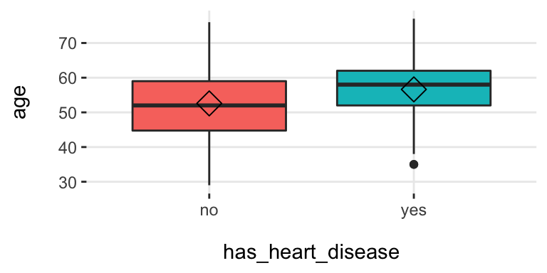

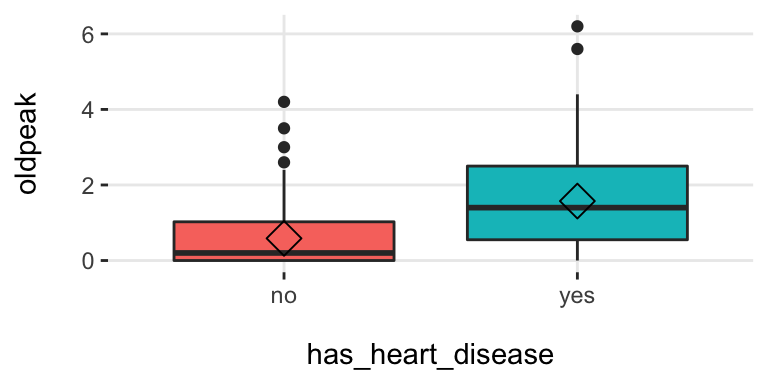

```r
plotar(data=heart_disease, str_input = c("age", "oldpeak"), str_target="has_heart_disease", plot_type="boxplot")
```

🔎 [Read more here.](https://livebook.datascienceheroes.com/selecting-best-variables.html#target-profiling-using-boxplots)

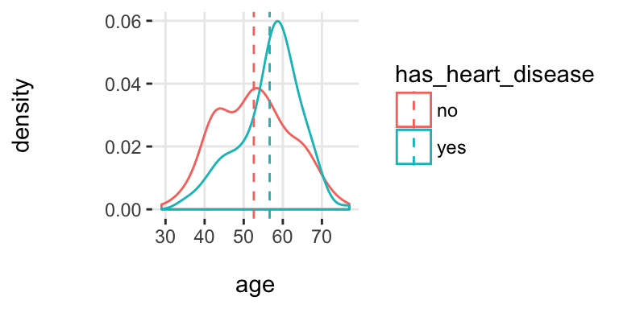

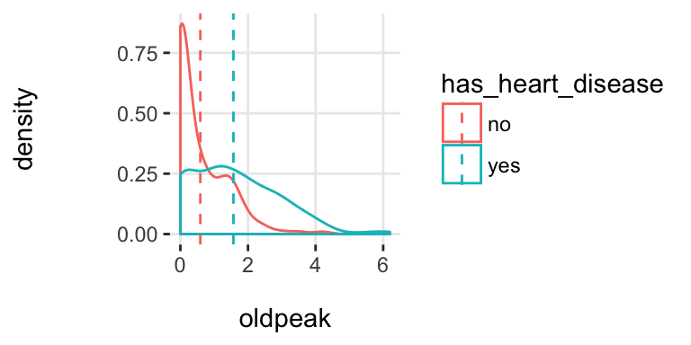

```r
plotar(data=heart_disease, str_input = c("age", "oldpeak"), str_target="has_heart_disease", plot_type="histdens")
```

🔎 [Read more here.](https://livebook.datascienceheroes.com/selecting-best-variables.html#target-profiling-using-density-histograms)

## Data preparation

### Data discretization

#### `discretize_get_bins` + `discretize_df`: Convert numeric variables into categoric

We need two functions: `discretize_get_bins` which returns the thresholds for each variable, and then `discretize_df` which takes the result from the first function and converts the desiered variables. The binning criteria is equal frequency.

Example converting only two variables from a dataset.

```r
# Step 1: Getting the thresholds for the desiered variables: "max_heart_rate" and "oldpeak"
d_bins=discretize_get_bins(data=heart_disease, input=c("max_heart_rate", "oldpeak"), n_bins=5)
```

```
## [1] "Variables processed: max_heart_rate, oldpeak"
```

```r
# Step 2: Applying the threshold to get final processed data frame
heart_disease_discretized=discretize_df(data=heart_disease, data_bins=d_bins, stringsAsFactors=T)
```

```
## [1] "Variables processed: max_heart_rate, oldpeak"
```

Following image will illustrate how the result is, please note that variable name will remaing the same.

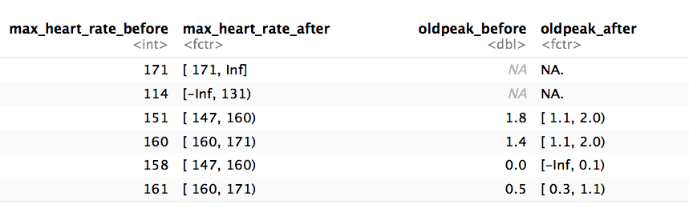

data discretization

🔎 [Read more here.](https://livebook.datascienceheroes.com/data-preparation.html#data-discretization)

#### `equal_freq`: Convert numeric variable into categoric

Converts numeric vector into a factor using equal frequency criteria.

```r
new_age=equal_freq(heart_disease$age, n_bins = 5)

# checking results
Hmisc::describe(new_age)
```

```
## new_age
##        n  missing distinct
##      303        0        5
##
## Value      [29,46) [46,54) [54,59) [59,63) [63,77]
## Frequency       63      64      71      45      60
## Proportion    0.21    0.21    0.23    0.15    0.20
```

🔎 [Read more here.](https://livebook.datascienceheroes.com/data-preparation.html#equal-frequency-binning)

#### `range01`: scales variable into 0 to 1 range

```r
age_scaled=range01(heart_disease$oldpeak)

# checking results
summary(age_scaled)
```

```
##    Min. 1st Qu.  Median    Mean 3rd Qu.    Max.
##    0.00    0.00    0.13    0.17    0.26    1.00
```

### Outliers Data Preparation

#### `hampel_outlier` and `tukey_outlier`: Gets outliers threshold

Both functions retrieves a two-value vector indicating the thresholds for which the values are considered as outliers.

Using Tukey’s method:

```r
tukey_outlier(heart_disease$resting_blood_pressure)
```

```
## bottom_threshold    top_threshold
##               60              200
```

🔎 [Read more here.](https://livebook.datascienceheroes.com/data-preparation.html#detecting-outliers-using-tukey-method)

Using Hampel’s method:

```r
hampel_outlier(heart_disease$resting_blood_pressure)
```

```
## bottom_threshold    top_threshold
##               86              174
```

🔎 [Read more here.](https://livebook.datascienceheroes.com/data-preparation.html#detecting-outliers-using-hampel-method)

Note: `tukey_outlier` and `hampel_outlier` are used internally in `prep_outliers`.

#### `prep_outliers`: Prepare outliers in a data frame

It takes a data frame, and returns the same data frame plus the transformations specified in the `str_input` parameter. It also works with a single vector.

```r
# Checking max and min value for 'max_heart_rate'
summary(heart_disease$max_heart_rate)
```

```
##    Min. 1st Qu.  Median    Mean 3rd Qu.    Max.
##      71     134     153     150     166     202
```

```r
# Get threshold according to Hampel's method
hampel_outlier(heart_disease$resting_blood_pressure)
```

```
## bottom_threshold    top_threshold
##               86              174
```

```r
# Apply function to stop outliers at the threshold values
data_prep=prep_outliers(data = heart_disease,
                                                str_input = c('max_heart_rate','resting_blood_pressure'),
                                                method = "hampel",
                                                type='stop')

# Check the results, the maximum value is now 174.5 (the minimum remains the same).
summary(data_prep$resting_blood_pressure)
```

```
##    Min. 1st Qu.  Median    Mean 3rd Qu.    Max.
##      94     120     130     131     140     174
```

Notes:

- `method` can be: `bottom_top`, `tukey` or `hampel`.
- `type` can be: `stop` or `set_na`. If `stop` all values flagged as outliers will be set to the threshold. If `set_na` the flagged values will set to `NA`.

🔎 [Read more here.](https://livebook.datascienceheroes.com/data-preparation.html#how_to_deal_with_outliers_in_r)